UNDER WORK!!!

# Age of onset with Dementia as an example (AOO_Dementia)

## Functions

Below is the R-functions created to make the analysis for the paper.

| R-function | Calculates |
| --- | --- |
| `CIF()` | The cumulative incidence function |
| `median_age()` | The median age from the CIF |
| `quantile_age()` | The quantile age from the CIF |
| `mean_age()` | The mean age from the CIF |
| `mean_age_of_onset()` | Combines the functions above to one function |
| `pseudo_theta()` | Used to compute AOO in creating the pseudo-observations |

### Libraries used

| Library | Used in |
| --- | --- |
| prodlim | Computing CIF in mean_age_of_onset() |
| pracma | mean_age() for calculating area below the curve |
| doParallel | Run the code quicker |
| foreach | Run the code quicker |
| ggplot2 | Creating plots |
| gridExtra | Creating panel plots |
| ggExtra | Adding marginal histogram |
| mgcv | Computing GAM |
| splines | Creating splines |
| dplyr | Data manipulation |

At each of the R-scripts, the packages used in a function is listed.

## Description of input data

We work in a competing risk set-up. The competing states are: Healthy, Diagnosed with dimentia (F00-F09), and Death & Emigration. Where the two last states are exiting states.

### Scenarios

Complete follow-up: The study looks at individuals who are alive and healthy in Denmark who turns 75 years old between 01/01/1994 and 31/12/2001. The study ends at the end of 2021, or when the indivuals turn 95 years old, or when entering an exiting state, whatever comes first. In this scenario we will possible have full follow-up of the individuals.

Total cohort: The study looks at individuals who are alive and healthy in Denmark who turns 75 years old between 01/01/1994 and 31/12/2021. The study ends at the end of 2021, or when the indivuals turn 95 years old, or when entering an exiting state, whatever comes first. In this scenario not all individuals can be in the study until there 95’th birthday.

The data structure is similar for the two scenarios. The code described is generalized, since the analysis is similar for the two scenarios. In practise the code is run for each of the scenarios.

### Data

| Column number | Column name | Description |
| --- | --- | --- |
| 1 | PID | Person ID |
| 2 | KQN | Sex |
| 3 | fdato | Date of birth |
| 5 | start_date | Date of entry in study |
| 6 | end_date | Date of exit of study |
| 7 | censor_stat | Censoring status at end of study (1: Healthy, 2: Diagnosed, 3: Death and emigration) |
| 8 | Tstart | Age at entry of study |
| 9 | Tslut | Age at exit of study |

In the code it will be calles “dat”.

### Data with pseudo observations

| Column number | Column name | Description |
| --- | --- | --- |
| 1 | PID | Person ID |
| 2 | KQN | Sex |
| 3 | fdato | Date of birth |
| 5 | start_date | Date of entry in study |
| 6 | end_date | Date of exit of study |
| 7 | censor_stat | Censoring status at end of study (1: Healthy, 2: Diagnosed, 3: Death and emigration) |
| 8 | Tstart | Age at entry of study |
| 9 | Tslut | Age at exit of study |
| 10 | theta | Pseudo-observation |
| 11 | coefYear2001 |  |

In the code it will be calles “dat_pse”.

### Availability of data and materials

Data for this study os property of Statistic Denmark and the Danish Health Data Authority. The data are available from the authorities, but restrictions apply.

## Analysis

File with computations of pseudo observations

Risk regression models

Computing linear model with splines

This is done similar in both scenarios, therefore the code is fairly similar and therefore will only be one example of the code.

## Math

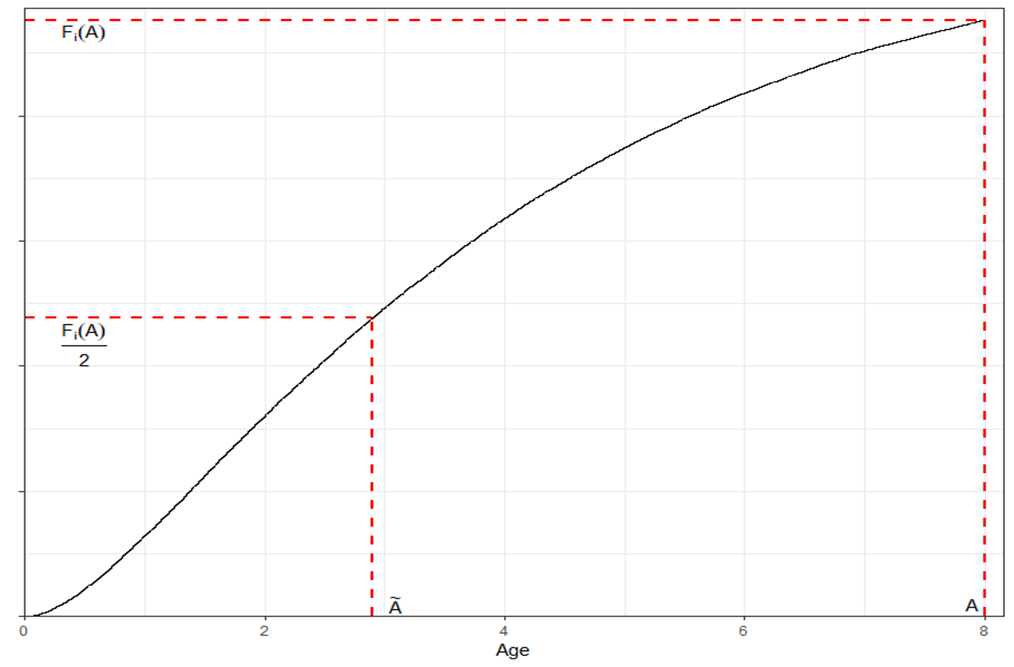

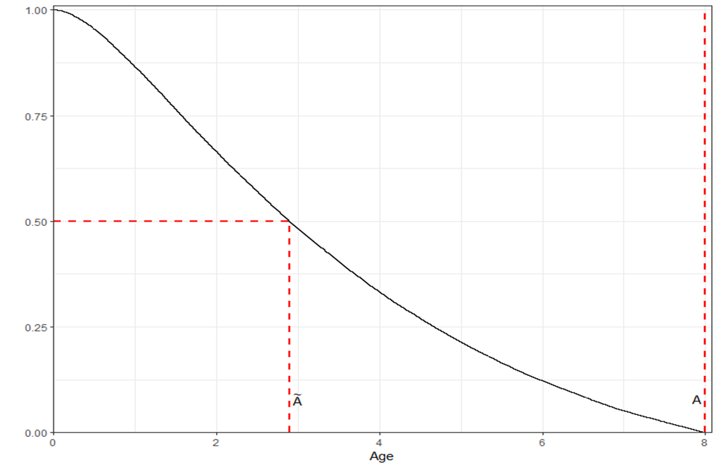

## Simulations

General information about the concept of the simulations.

### Aim for simulation:

We wish to compare methods for estimating the mean age of onset (MAOO) in competing risk survival analysis. We wish to validate our method.

### Metrics for methods

- Average of means
- Average of se(means)
- Absolute bias
- Relative bias
- Relative root mean squared error
- MSE/RMSE
- Quantiles
- Coverage probability

(Monte Carlo SE of estimates)